# R Notebook

### **Exploratory Data Analysis (EDA)**

Let’s combine what we learned so far in the course to do a full EDA of the bikes dataset. We’ll also show how to do PCA as a bonus.

First, load in all libraries and the dataset.

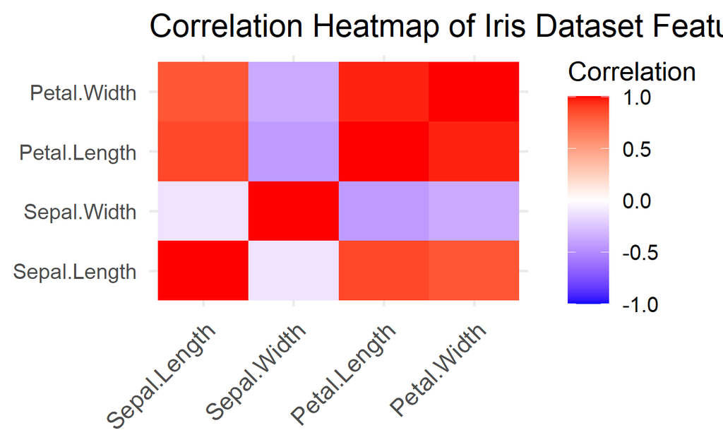

```r
data(iris)
library(tidyverse)
library(reshape2)

# Calculate the correlation matrix
iris_cor <- cor(iris[, 1:4])

# Melt the correlation matrix into a long format for ggplot2
iris_cor_melted <- melt(iris_cor)

# Create the heatmap
ggplot(iris_cor_melted, aes(x = Var1, y = Var2, fill = value)) +
  geom_tile() +
  scale_fill_gradient2(low = "blue", high = "red", mid = "white",
                       midpoint = 0, limit = c(-1,1), space = "Lab",
                       name="Correlation") +
  theme_minimal() +
  labs(title = "Correlation Heatmap of Iris Dataset Features") +
  theme(axis.text.x = element_text(angle = 45, vjust = 1,
                                   size = 10, hjust = 1),
        axis.title = element_blank())
```

```r
library(readr)

bike_data = read.csv("C:/Users/coryg/Downloads/bike_buyers.csv", header = TRUE, na.string='')

head(bike_data, 10)
```

|  | ID | Marital.Status | Gender | Income | Children | Education | Occupation | Home.Owner | Cars | Commute.Distance | Region | Age | Purchased.Bike |
| --- | --- | --- | --- | --- | --- | --- | --- | --- | --- | --- | --- | --- | --- |
| 1 | 12496 | Married | Female | 40000 | 1 | Bachelors | Skilled Manual | Yes | 0 | 0-1 Miles | Europe | 42 | No |
| 2 | 24107 | Married | Male | 30000 | 3 | Partial College | Clerical | Yes | 1 | 0-1 Miles | Europe | 43 | No |
| 3 | 14177 | Married | Male | 80000 | 5 | Partial College | Professional | No | 2 | 2-5 Miles | Europe | 60 | No |
| 4 | 24381 | Single | NA | 70000 | 0 | Bachelors | Professional | Yes | 1 | 5-10 Miles | Pacific | 41 | Yes |
| 5 | 25597 | Single | Male | 30000 | 0 | Bachelors | Clerical | No | 0 | 0-1 Miles | Europe | 36 | Yes |
| 6 | 13507 | Married | Female | 10000 | 2 | Partial College | Manual | Yes | 0 | 1-2 Miles | Europe | 50 | No |
| 7 | 27974 | Single | Male | 160000 | 2 | High School | Management | NA | 4 | 0-1 Miles | Pacific | 33 | Yes |
| 8 | 19364 | Married | Male | 40000 | 1 | Bachelors | Skilled Manual | Yes | 0 | 0-1 Miles | Europe | 43 | Yes |
| 9 | 22155 | NA | Male | 20000 | 2 | Partial High School | Clerical | Yes | 2 | 5-10 Miles | Pacific | 58 | No |
| 10 | 19280 | Married | Male | NA | 2 | Partial College | Manual | Yes | 1 | 0-1 Miles | Europe | NA | Yes |

Take a peek at some of the datatypes and observations.

```r
str(bike_data)
```

```
'data.frame':   1000 obs. of  13 variables:
 $ ID              : int  12496 24107 14177 24381 25597 13507 27974 19364 22155 19280 ...
 $ Marital.Status  : chr  "Married" "Married" "Married" "Single" ...
 $ Gender          : chr  "Female" "Male" "Male" NA ...
 $ Income          : int  40000 30000 80000 70000 30000 10000 160000 40000 20000 NA ...
 $ Children        : int  1 3 5 0 0 2 2 1 2 2 ...
 $ Education       : chr  "Bachelors" "Partial College" "Partial College" "Bachelors" ...
 $ Occupation      : chr  "Skilled Manual" "Clerical" "Professional" "Professional" ...
 $ Home.Owner      : chr  "Yes" "Yes" "No" "Yes" ...
 $ Cars            : int  0 1 2 1 0 0 4 0 2 1 ...
 $ Commute.Distance: chr  "0-1 Miles" "0-1 Miles" "2-5 Miles" "5-10 Miles" ...
 $ Region          : chr  "Europe" "Europe" "Europe" "Pacific" ...
 $ Age             : int  42 43 60 41 36 50 33 43 58 NA ...
 $ Purchased.Bike  : chr  "No" "No" "No" "Yes" ...
```

Summarize the data with summary().

```r
summary(bike_data)
```

```
       ID        Marital.Status
 Min.   :11000   Length:1000
 1st Qu.:15291   Class :character
 Median :19744   Mode  :character
 Mean   :19966
 3rd Qu.:24471
 Max.   :29447

    Gender              Income
 Length:1000        Min.   : 10000
 Class :character   1st Qu.: 30000
 Mode  :character   Median : 60000
                    Mean   : 56268
                    3rd Qu.: 70000
                    Max.   :170000
                    NA's   :6
    Children     Education
 Min.   :0.00   Length:1000
 1st Qu.:0.00   Class :character
 Median :2.00   Mode  :character
 Mean   :1.91
 3rd Qu.:3.00
 Max.   :5.00
 NA's   :8
  Occupation
 Length:1000
 Class :character
 Mode  :character




  Home.Owner             Cars
 Length:1000        Min.   :0.000
 Class :character   1st Qu.:1.000
 Mode  :character   Median :1.000
                    Mean   :1.455
                    3rd Qu.:2.000
                    Max.   :4.000
                    NA's   :9
 Commute.Distance
 Length:1000
 Class :character
 Mode  :character




    Region               Age
 Length:1000        Min.   :25.00
 Class :character   1st Qu.:35.00
 Mode  :character   Median :43.00
                    Mean   :44.18
                    3rd Qu.:52.00
                    Max.   :89.00
                    NA's   :8
 Purchased.Bike
 Length:1000
 Class :character
 Mode  :character
```

We can check levels of categorical features by using levels(). Note that prior to using levels(), your categorical feature must be converted to a factor datatype.

```r
bike_data$Marital.Status = as.factor(bike_data$Marital.Status)

bike_data$Gender = as.factor(bike_data$Gender)

bike_data$Home.Owner = as.factor(bike_data$Home.Owner)

bike_data$Purchased.Bike = as.factor(bike_data$Purchased.Bike)

levels(bike_data$Gender)
```

```
[1] "Female" "Male"
```

Now let’s check for missing values, I’ve shown you one way to do this during data cleaning, here’s another way to do the same thing.

```r
colSums(is.na(bike_data))
```

```
              ID   Marital.Status
               0                7
          Gender           Income
              11                6
        Children        Education
               8                0
      Occupation       Home.Owner
               0                4
            Cars Commute.Distance
               9                0
          Region              Age
               0                8
  Purchased.Bike
               0
```

Prior to cleaning, let’s visualize our data to see trends about some of the features’ distributions that have missing values.

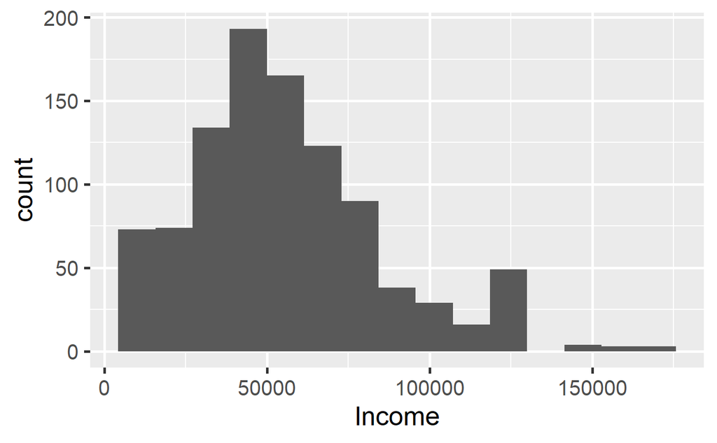

```r
ggplot(data = bike_data) +
  geom_histogram(mapping = aes(x = Income), bins = 15)
```

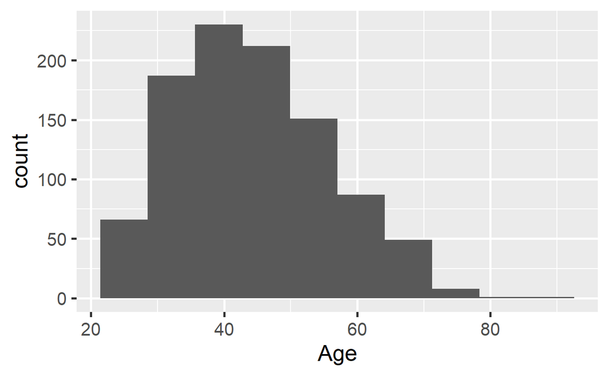

```r
ggplot(data = bike_data) +
  geom_histogram(mapping = aes(x = Age), bins = 10)
```

Income and Age are continuous numerical features that are right skewed, hence the appropriate imputation method for missing values is median imputation.

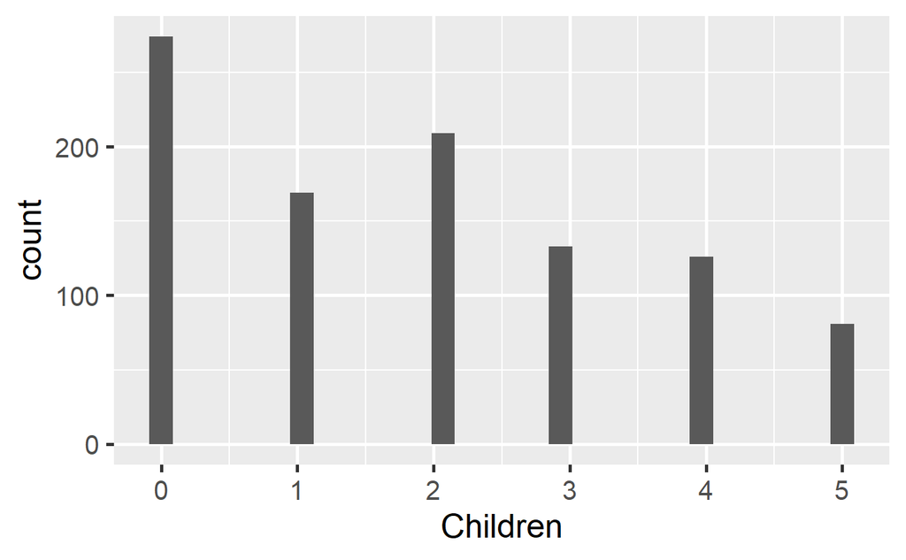

```r
ggplot(data = bike_data) +
  geom_histogram(mapping = aes(x = Children))
```

```r
bike_data_clean = bike_data

bike_data_clean$Income[is.na(bike_data_clean$Income)] = median(bike_data_clean$Income, na.rm = TRUE)

bike_data_clean$Age[is.na(bike_data_clean$Age)] = median(bike_data_clean$Age, na.rm = TRUE)
```

Now for the categorical variables, we’ll replace the missing values with the most frequent categorical value, and you guessed it, this technique would be called mode imputation, very similar to how median and mean imputation works.

For mode imputation, mode is not a built-in function, so we’ll need to create it as a custom function.

```r
get_mode = function(x) {
  unique_x = unique(x)
  tabulation = tabulate(match(x, unique_x))
  unique_x[tabulation == max(tabulation)]
}
```

```r
bike_data_clean$Marital.Status[is.na(bike_data_clean$Marital.Status)] = get_mode(bike_data_clean$Marital.Status)

bike_data_clean$Gender[is.na(bike_data_clean$Gender)] = get_mode(bike_data_clean$Gender)

bike_data_clean$Home.Owner[is.na(bike_data_clean$Home.Owner)] = get_mode(bike_data_clean$Home.Owner)

bike_data_clean$Children[is.na(bike_data_clean$Children)] = get_mode(bike_data_clean$Children)
```

Now for Cars, let’s try mean imputation.

```r
bike_data_clean$Cars[is.na(bike_data_clean$Cars)] = mean(bike_data_clean$Cars, na.rm = TRUE)
```

```r
colSums(is.na(bike_data_clean))
```

```
              ID   Marital.Status
               0                0
          Gender           Income
               0                0
        Children        Education
               0                0
      Occupation       Home.Owner
               0                0
            Cars Commute.Distance
               0                0
          Region              Age
               0                0
  Purchased.Bike
               0
```

Now how about some scatterplots between a couple categorical and numerical features? For example, maybe between gender and age…

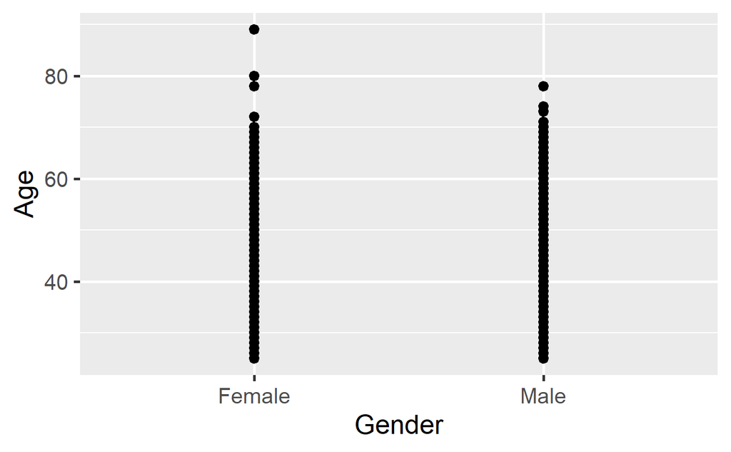

```r
bike_data = bike_data_clean

ggplot(data = bike_data, aes(x = Gender, y = Age)) + geom_point()
```

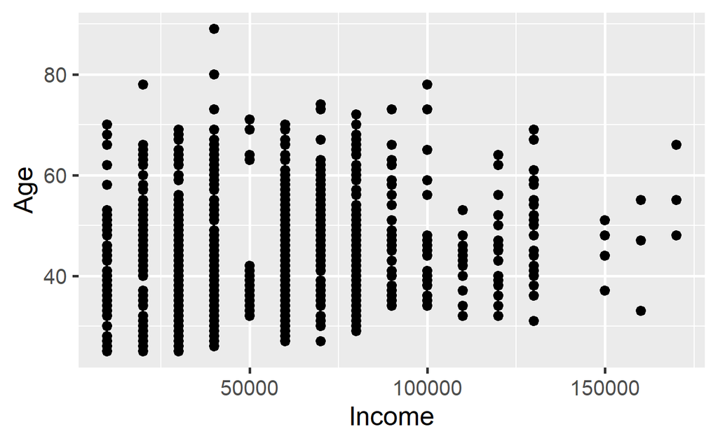

```r
ggplot(data = bike_data, aes(x = Income, y = Age)) + geom_point()
```

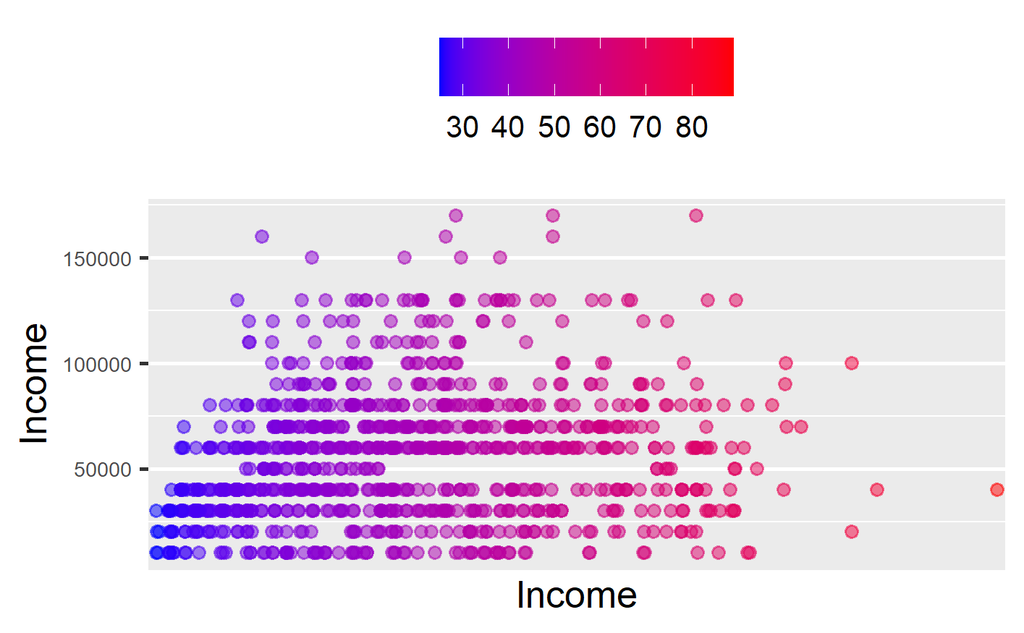

```r
p3 <- ggplot(bike_data,
             aes(x = Age,
                 y = Income)) +
  theme(legend.position="top",
        axis.text=element_text(size = 6))
p4 <- p3 + geom_point(aes(color = Age),
                       alpha = 0.5,
                       size = 1.5,
                       position = position_jitter(width = 0.25, height = 0))
p4 +
  scale_x_discrete(name="Income") +
  scale_color_continuous(name="", low = "blue", high = "red")
```

Now another special plot used for an EDA against numerical and categorical features is a line plot.

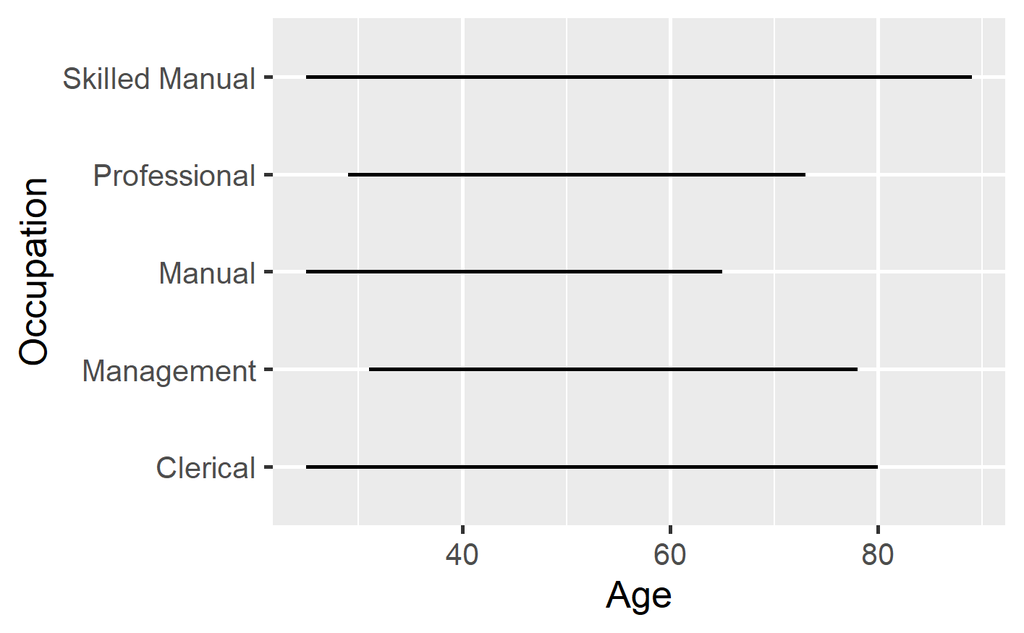

```r
ggplot(data = bike_data) +
  geom_line(mapping = aes(x = Age, y = Occupation))
```

To add another dimension to this, say gender, let’s use our friend facet_wrap().

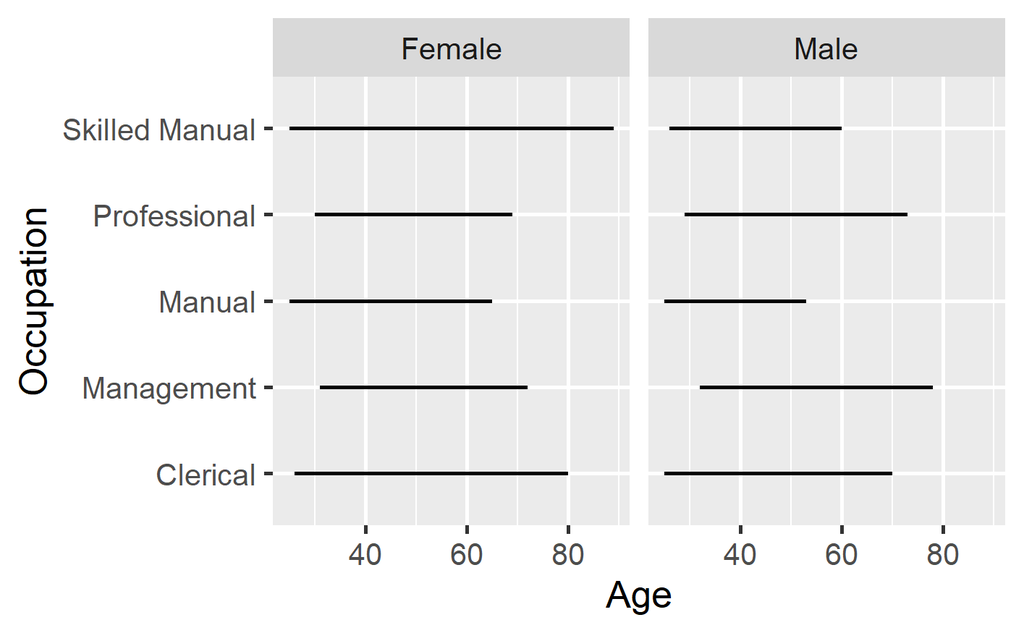

```r
ggplot(data = bike_data) +
  geom_line(mapping = aes(x = Age, y = Occupation)) + facet_wrap(~Gender, ncol = 10)
```

Now let’s look at some boxplots. For simplicity of this example in the notes, let’s just do Income by Age.

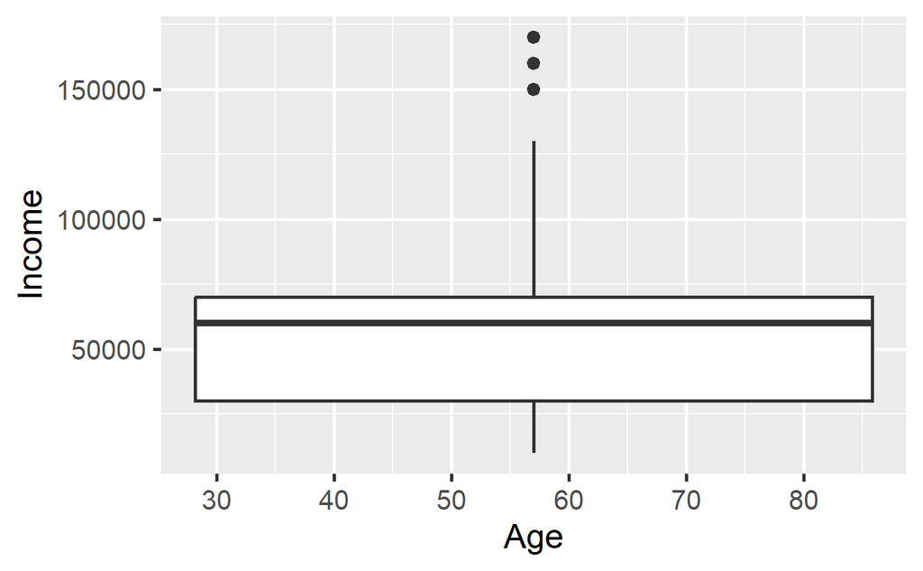

```r
ggplot(data = bike_data, mapping = aes( x = Age, y = Income)) + geom_boxplot()
```

Any outliers by Income? Let’s detect them and filter them out from the dataset (alternatively you can cap your outliers if your dataset is considerably small).

```r
x = bike_data$Income
Q1 = quantile(x, 0.25, na.rm = TRUE)
Q3 = quantile(x, 0.75, na.rm = TRUE)
IQR = Q3 - Q1

outliers = x < (Q1 - 1.5*IQR) | x > (Q3 + 1.5*IQR)

bike_data[outliers,]
```

|  | ID | Marital.Status | Gender | Income | Children | Education | Occupation | Home.Owner | Cars | Commute.Distance | Region | Age | Purchased.Bike |
| --- | --- | --- | --- | --- | --- | --- | --- | --- | --- | --- | --- | --- | --- |
| 7 | 27974 | Single | Male | 160000 | 2 | High School | Management | Yes | 4.000000 | 0-1 Miles | Pacific | 33 | Yes |
| 13 | 11434 | Married | Male | 170000 | 5 | Partial College | Professional | Yes | 1.455096 | 0-1 Miles | Europe | 55 | No |
| 44 | 17185 | Married | Female | 170000 | 4 | Partial College | Professional | No | 3.000000 | 5-10 Miles | Europe | 48 | Yes |
| 122 | 15922 | Married | Male | 150000 | 2 | High School | Professional | Yes | 4.000000 | 0-1 Miles | Europe | 48 | No |
| 179 | 14191 | Married | Male | 160000 | 4 | Partial College | Professional | No | 2.000000 | 10+ Miles | Europe | 55 | Yes |
| 260 | 12705 | Married | Male | 150000 | 0 | Bachelors | Management | Yes | 4.000000 | 0-1 Miles | Pacific | 37 | Yes |
| 322 | 16675 | Single | Female | 160000 | 0 | Graduate Degree | Management | No | 3.000000 | 0-1 Miles | Pacific | 47 | Yes |
| 357 | 23608 | Married | Female | 150000 | 3 | High School | Professional | Yes | 3.000000 | 0-1 Miles | Europe | 51 | Yes |
| 830 | 16009 | Single | Male | 170000 | 1 | Graduate Degree | Management | No | 4.000000 | 0-1 Miles | North America | 66 | No |
| 994 | 11292 | Single | Male | 150000 | 1 | Partial College | Professional | No | 3.000000 | 0-1 Miles | North America | 44 | Yes |

Dropping and checking to see if outliers were dropped.

```r
bike_data = bike_data[-c(7, 13, 44, 122, 179, 260, 322, 357, 830, 994),]

nrow(bike_data)
```

```
[1] 990
```

Finally, let’s take a look at PCA. For a simple example, we’ll use the Iris dataset. Note that you’ll need to remove categorical features prior to doing PCA.

```r
data(iris)
iris_pca_data = iris[, -5]

pca_result = prcomp(iris_pca_data, scale = TRUE)

# View the standard deviations of the principal components

print(pca_result$sdev)
```

```
[1] 1.7083611 0.9560494 0.3830886
[4] 0.1439265
```

```r
# View the rotation (loadings) matrix, showing how original variables contribute to PCs

print(pca_result$rotation)
```

```
                    PC1         PC2
Sepal.Length  0.5210659 -0.37741762
Sepal.Width  -0.2693474 -0.92329566
Petal.Length  0.5804131 -0.02449161
Petal.Width   0.5648565 -0.06694199
                    PC3        PC4
Sepal.Length  0.7195664  0.2612863
Sepal.Width  -0.2443818 -0.1235096
Petal.Length -0.1421264 -0.8014492
Petal.Width  -0.6342727  0.5235971
```

```r
# View the principal component scores for each observation

print(pca_result$x)
```

```
               PC1          PC2
  [1,] -2.25714118 -0.478423832
  [2,] -2.07401302  0.671882687
  [3,] -2.35633511  0.340766425
  [4,] -2.29170679  0.595399863
  [5,] -2.38186270 -0.644675659
  [6,] -2.06870061 -1.484205297
  [7,] -2.43586845 -0.047485118
  [8,] -2.22539189 -0.222403002
  [9,] -2.32684533  1.111603700
 [10,] -2.17703491  0.467447569
 [11,] -2.15907699 -1.040205867
 [12,] -2.31836413 -0.132633999
 [13,] -2.21104370  0.726243183
 [14,] -2.62430902  0.958296347
```

[output cut: 287 more lines]

```r
# Get a summary of the PCA results, including explained variance

summary(pca_result)
```

```
Importance of components:
                          PC1    PC2
Standard deviation     1.7084 0.9560
Proportion of Variance 0.7296 0.2285
Cumulative Proportion  0.7296 0.9581
                           PC3
Standard deviation     0.38309
Proportion of Variance 0.03669
Cumulative Proportion  0.99482
                           PC4
Standard deviation     0.14393
Proportion of Variance 0.00518
Cumulative Proportion  1.00000
```

From these results, we can see that there are 4 principal components that were found, and the most variation within our data is explained by principal components 1 and 2. So starting with 4 features (4th dimensional data), we reduced our data to two new dimensions, namely principal components 1 and 2. To visualize the principal components, we can use the ggbiplot package.

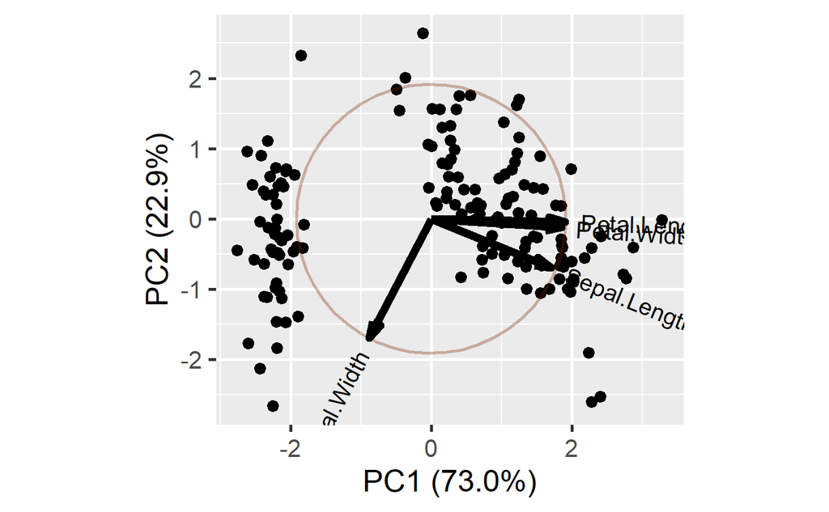

```r
#install.packages("ggbiplot")
library(ggbiplot)

ggbiplot(pca_result, obs.scale = 1, var.scale = 1, ellipse = TRUE, circle = TRUE)
```